# Cyclistic Bike Share: Case Study

Nasraddin Gozalli

2023-09-22

## Introduction

This capstone project is a component of my Google Data Analytics Professional Certificate program. In this analysis, I will utilize the R programming language and the RStudio IDE due to their convenient statistical analysis capabilities and effective data visualization tools.

**For this project following data analysis steps will be followed:**

**Ask** **Prepare** **Process** **Analyze** **Share** **Act**

The data analysis process will adhere to the following case study roadmap, which includes: - coding as necessary at each step - key tasks as a checklist - deliverables as a checklist.

**Scenario**

You are a junior data analyst working in the marketing analyst team at Cyclistic, a bike-share company in Chicago. The director of marketing believes the company’s future success depends on maximizing the number of annual memberships. Therefore, your team wants to understand how casual riders and annual members use Cyclistic bikes differently. From these insights, your team will design a new marketing strategy to convert casual riders into annual members. But first, Cyclistic executives must approve your recommendations, so they must be backed up with compelling data insights and professional data visualizations.

## Ask

**Three questions will guide the future marketing program:**

1. How do annual members and casual riders use Cyclistic bikes differently?
2. Why would casual riders buy Cyclistic annual memberships?
3. How can Cyclistic use digital media to influence casual riders to become members?

The director of marketing and your manager Lily Moreno has assigned you the first question to answer: How do annual members and casual riders use Cyclistic bikes differently?

**Key tasks**

**Identify the business task**

**Our main aim is to figure out how we can get casual bike riders to become annual members by looking into how these two groups, ‘Casual’ and ‘Annual’ customers, use Cyclistic bike share differently.**

**Consider key stakeholders** **The Cyclistic executive team, led by Director of Marketing Lily Moreno, along with the Marketing Analytics squad.**

## Prepare

I will utilize Cyclistic’s historical trip data to conduct an analysis and identify prevailing trends. The data has been generously made available by Motivate International Inc. and is governed by their licensing terms. The datasets can be accessed here.

**Key Tasks**

**Download and securely store the data**

- Data has been successfully downloaded from the provided source and securely saved on my local computer as well as on Kaggle.

**Determine the data’s structure and organization**

- The trip data is presented in a comma-delimited (.CSV) format. It encompasses the following columns: “ride_id,” “rideable_type,” “started_at,” “ended_at,” “start_station_name,” “start_station_id,” “end_station_name,” “end_station_id,” “start_lat,” “start_lng,” “end_lat,” “end_lng,” and “member_casual” (a total of 13 columns).

**Sort and filter the data**

**Verify the data’s reliability**

- The datasets are considered suitable for the purposes of this case study and are conducive to answering the business inquiries. However, due to privacy considerations, personally identifiable rider information cannot be utilized, making it impossible to determine if a single user has taken multiple rides. It’s important to note that all ride IDs within this dataset are unique.

**Deliverable** - A comprehensive description of all data sources used.

The primary data source for this analysis is provided by Cyclistic, the parent company.

**Lets collect and combine data into one dataframe**

```r
#install and load necessary libraries

library(tidyverse) # data wragling
library(janitor) # data cleaning
```

```r
library(lubridate) # wragle data attributies
library(ggplot2) # data vizz
library(dplyr) # count distinct
library(ggmap)
library(geosphere)
```

```r
# Import Data

# Define the directory path where the CSV files are located.
file_list <- list.files(path = "/Users/nasraddingozalli/Desktop/Case Study 1/Bike_share/", pattern = "\\.csv$", full.names = TRUE)

# Read and load all CSV files from the specified directory.
all_rides <- lapply(file_list, read.csv)

# Combine (concatenate) all individual data frames into a single data frame.
all_rides <- bind_rows(all_rides)
```

## Process

*Cleaning and Preparation of Data for Analysis*

**Key Tasks**

*Check the data for errors* *Choose your tools* *Transform the data so you can work with it effectively* *Document the cleaning process*

**Deliverable**

*Documentation of any cleaning or manipulation of data*

```r
# Display the column names of the 'all_rides' data frame.
colnames(all_rides)
```

```
##  [1] "ride_id"            "rideable_type"      "started_at"
##  [4] "ended_at"           "start_station_name" "start_station_id"
##  [7] "end_station_name"   "end_station_id"     "start_lat"
## [10] "start_lng"          "end_lat"            "end_lng"
## [13] "member_casual"
```

```r
# Display the first few rows of the 'all_rides' data frame.
head(all_rides)
```

```
##            ride_id rideable_type          started_at            ended_at
## 1 C2F7DD78E82EC875 electric_bike 2022-01-13 11:59:47 2022-01-13 12:02:44
## 2 A6CF8980A652D272 electric_bike 2022-01-10 08:41:56 2022-01-10 08:46:17
## 3 BD0F91DFF741C66D  classic_bike 2022-01-25 04:53:40 2022-01-25 04:58:01
## 4 CBB80ED419105406  classic_bike 2022-01-04 00:18:04 2022-01-04 00:33:00
## 5 DDC963BFDDA51EEA  classic_bike 2022-01-20 01:31:10 2022-01-20 01:37:12
## 6 A39C6F6CC0586C0B  classic_bike 2022-01-11 18:48:09 2022-01-11 18:51:31
##              start_station_name start_station_id              end_station_name
## 1      Glenwood Ave & Touhy Ave              525          Clark St & Touhy Ave
## 2      Glenwood Ave & Touhy Ave              525          Clark St & Touhy Ave
## 3 Sheffield Ave & Fullerton Ave     TA1306000016 Greenview Ave & Fullerton Ave
## 4      Clark St & Bryn Mawr Ave     KA1504000151     Paulina St & Montrose Ave
## 5   Michigan Ave & Jackson Blvd     TA1309000002        State St & Randolph St
## 6         Wood St & Chicago Ave              637       Honore St & Division St
##   end_station_id start_lat start_lng  end_lat   end_lng member_casual
## 1         RP-007  42.01280 -87.66591 42.01256 -87.67437        casual
## 2         RP-007  42.01276 -87.66597 42.01256 -87.67437        casual
## 3   TA1307000001  41.92560 -87.65371 41.92533 -87.66580        member
## 4   TA1309000021  41.98359 -87.66915 41.96151 -87.67139        casual
## 5   TA1305000029  41.87785 -87.62408 41.88462 -87.62783        member
## 6   TA1305000034  41.89563 -87.67207 41.90312 -87.67394        member
```

```r
# Show the structure of the 'all_rides' data frame.
str(all_rides)
```

```
## 'data.frame':    5667717 obs. of  13 variables:
##  $ ride_id           : chr  "C2F7DD78E82EC875" "A6CF8980A652D272" "BD0F91DFF741C66D" "CBB80ED419105406" ...
##  $ rideable_type     : chr  "electric_bike" "electric_bike" "classic_bike" "classic_bike" ...
##  $ started_at        : chr  "2022-01-13 11:59:47" "2022-01-10 08:41:56" "2022-01-25 04:53:40" "2022-01-04 00:18:04" ...
##  $ ended_at          : chr  "2022-01-13 12:02:44" "2022-01-10 08:46:17" "2022-01-25 04:58:01" "2022-01-04 00:33:00" ...
##  $ start_station_name: chr  "Glenwood Ave & Touhy Ave" "Glenwood Ave & Touhy Ave" "Sheffield Ave & Fullerton Ave" "Clark St & Bryn Mawr Ave" ...
##  $ start_station_id  : chr  "525" "525" "TA1306000016" "KA1504000151" ...
##  $ end_station_name  : chr  "Clark St & Touhy Ave" "Clark St & Touhy Ave" "Greenview Ave & Fullerton Ave" "Paulina St & Montrose Ave" ...
##  $ end_station_id    : chr  "RP-007" "RP-007" "TA1307000001" "TA1309000021" ...
##  $ start_lat         : num  42 42 41.9 42 41.9 ...
##  $ start_lng         : num  -87.7 -87.7 -87.7 -87.7 -87.6 ...
##  $ end_lat           : num  42 42 41.9 42 41.9 ...
##  $ end_lng           : num  -87.7 -87.7 -87.7 -87.7 -87.6 ...
##  $ member_casual     : chr  "casual" "casual" "member" "casual" ...
```

```r
# Provide a summary of the 'all_rides' data frame.
summary(all_rides)
```

```
##    ride_id          rideable_type       started_at          ended_at
##  Length:5667717     Length:5667717     Length:5667717     Length:5667717
##  Class :character   Class :character   Class :character   Class :character
##  Mode  :character   Mode  :character   Mode  :character   Mode  :character
##
##
##
##
##  start_station_name start_station_id   end_station_name   end_station_id
##  Length:5667717     Length:5667717     Length:5667717     Length:5667717
##  Class :character   Class :character   Class :character   Class :character
##  Mode  :character   Mode  :character   Mode  :character   Mode  :character
##
##
##
##
##    start_lat       start_lng         end_lat         end_lng
##  Min.   :41.64   Min.   :-87.84   Min.   : 0.00   Min.   :-88.14
##  1st Qu.:41.88   1st Qu.:-87.66   1st Qu.:41.88   1st Qu.:-87.66
##  Median :41.90   Median :-87.64   Median :41.90   Median :-87.64
##  Mean   :41.90   Mean   :-87.65   Mean   :41.90   Mean   :-87.65
##  3rd Qu.:41.93   3rd Qu.:-87.63   3rd Qu.:41.93   3rd Qu.:-87.63
##  Max.   :45.64   Max.   :-73.80   Max.   :42.37   Max.   :  0.00
##                                   NA's   :5858    NA's   :5858
##  member_casual
##  Length:5667717
##  Class :character
##  Mode  :character
##
##
##
##
```

Below code chunk is used to convert the `started_at` and `ended_at` columns of the `all_rides` data frame to datetime objects using the ymd_hms function. This conversion is necessary to facilitate time-related analysis, manipulation, and visualization of the data.

```r
# Convert date/time columns to datetime objects

# Convert 'started_at' column to datetime
all_rides$started_at <- ymd_hms(all_rides$started_at)

# Convert 'ended_at' column to datetime
all_rides$ended_at <- ymd_hms(all_rides$ended_at)
```

This code extends the ‘all_rides’ data frame by adding new columns that provide additional time-related information and the calculated ride length. These columns will be useful for more detailed analysis and insights into ride patterns.

```r
# Adding date, month, year, day of the week, ride length, and start time columns

all_rides_v1 <- all_rides %>%

  # Extract year
  mutate(year = format(as.Date(started_at), "%Y")) %>%

  # Extract month
  mutate(month = format(as.Date(started_at), "%B")) %>%

  # Extract date
  mutate(date = format(as.Date(started_at), "%d")) %>%

  # Extract day of the week
  mutate(day_of_week = format(as.Date(started_at), "%A")) %>%

  # Calculate ride length (in seconds)
  mutate(ride_length = as.numeric(difftime(ended_at, started_at))) %>%

  # Extract start time (hour)
  mutate(start_time = strftime(started_at, format = "%H"))
```

This code snippet calculates and adds a `ride_distance` column to the `all_rides_v1` data frame, representing the distance traveled by each ride in kilometers. It uses the distGeo function to calculate the geodesic (great-circle) distance between the start and end coordinates of each ride. The resulting distance is then converted from meters to kilometers.

```r
# Adding ride distance in kilometers column

# Calculate geodesic distance between start and end coordinates in meters
all_rides_v1$ride_distance <- distGeo(
  matrix(c(all_rides_v1$start_lng, all_rides_v1$start_lat), ncol = 2),
  matrix(c(all_rides_v1$end_lng, all_rides_v1$end_lat), ncol = 2)
)

# Convert distance from meters to kilometers
all_rides_v1$ride_distance <- all_rides_v1$ride_distance / 1000  # Distance in kilometers
```

**Data Refinement: Removing Anomalies**

In this section, we are systematically addressing data anomalies within the `all_rides_v1` dataset. Specifically, we are targeting instances where bicycles were apparently removed from docks without accompanying legitimate rides, denoted by ride lengths less than or equal to zero.

```r
# Remove bad data

# Remove rows with missing values (NA)
all_rides_v1 <- na.omit(all_rides_v1)

# Remove rows with ride lengths less than or equal to zero
all_rides_v1 <- all_rides_v1[!(all_rides_v1$ride_length <= 0),]
```

```r
# Convert member_casual to a factor
all_rides_v1$member_casual <- as.factor(all_rides_v1$member_casual)
```

```r
# Check for and remove duplicate rows (if any)
all_rides_v1 <- distinct(all_rides_v1)
```

##Analysis Phase

Now that all the essential data is consolidated and primed for examination.

**Key Objectives** *Aggregate the data for practicality and ease of use* *Arrange and structure the data appropriately* *Execute calculations and computations* *Detect patterns and correlations*

**Summary of Analytical Insights**

The upcoming code segments will be harnessed during this analytical phase to compare the behaviors of members and casual users:

```r
# Display the structure of the 'all_rides_v1' data frame
str(all_rides_v1)
```

```
## 'data.frame':    5661328 obs. of  20 variables:
##  $ ride_id           : chr  "C2F7DD78E82EC875" "A6CF8980A652D272" "BD0F91DFF741C66D" "CBB80ED419105406" ...
##  $ rideable_type     : chr  "electric_bike" "electric_bike" "classic_bike" "classic_bike" ...
##  $ started_at        : POSIXct, format: "2022-01-13 11:59:47" "2022-01-10 08:41:56" ...
##  $ ended_at          : POSIXct, format: "2022-01-13 12:02:44" "2022-01-10 08:46:17" ...
##  $ start_station_name: chr  "Glenwood Ave & Touhy Ave" "Glenwood Ave & Touhy Ave" "Sheffield Ave & Fullerton Ave" "Clark St & Bryn Mawr Ave" ...
##  $ start_station_id  : chr  "525" "525" "TA1306000016" "KA1504000151" ...
##  $ end_station_name  : chr  "Clark St & Touhy Ave" "Clark St & Touhy Ave" "Greenview Ave & Fullerton Ave" "Paulina St & Montrose Ave" ...
##  $ end_station_id    : chr  "RP-007" "RP-007" "TA1307000001" "TA1309000021" ...
##  $ start_lat         : num  42 42 41.9 42 41.9 ...
##  $ start_lng         : num  -87.7 -87.7 -87.7 -87.7 -87.6 ...
##  $ end_lat           : num  42 42 41.9 42 41.9 ...
##  $ end_lng           : num  -87.7 -87.7 -87.7 -87.7 -87.6 ...
##  $ member_casual     : Factor w/ 2 levels "casual","member": 1 1 2 1 2 2 2 2 2 2 ...
##  $ year              : chr  "2022" "2022" "2022" "2022" ...
##  $ month             : chr  "January" "January" "January" "January" ...
##  $ date              : chr  "13" "10" "25" "04" ...
##  $ day_of_week       : chr  "Thursday" "Monday" "Tuesday" "Tuesday" ...
##  $ ride_length       : num  177 261 261 896 362 ...
##  $ start_time        : chr  "12" "09" "05" "01" ...
##  $ ride_distance     : num  0.701 0.696 1.003 2.46 0.814 ...
##  - attr(*, "na.action")= 'omit' Named int [1:5858] 19718 19747 20466 20526 20654 20658 20732 20781 20800 21020 ...
##   ..- attr(*, "names")= chr [1:5858] "19718" "19747" "20466" "20526" ...
```

```r
# Provide a summary of the 'all_rides_v1' data frame
summary(all_rides_v1)
```

```
##    ride_id          rideable_type        started_at
##  Length:5661328     Length:5661328     Min.   :2022-01-01 00:00:05.00
##  Class :character   Class :character   1st Qu.:2022-05-28 19:15:59.00
##  Mode  :character   Mode  :character   Median :2022-07-22 15:09:51.50
##                                        Mean   :2022-07-20 07:25:23.64
##                                        3rd Qu.:2022-09-16 07:36:19.00
##                                        Max.   :2022-12-31 23:59:26.00
##     ended_at                      start_station_name start_station_id
##  Min.   :2022-01-01 00:01:48.00   Length:5661328     Length:5661328
##  1st Qu.:2022-05-28 19:36:34.75   Class :character   Class :character
##  Median :2022-07-22 15:28:14.50   Mode  :character   Mode  :character
##  Mean   :2022-07-20 07:41:43.51
##  3rd Qu.:2022-09-16 07:50:02.00
##  Max.   :2023-01-01 18:09:37.00
##  end_station_name   end_station_id       start_lat       start_lng
##  Length:5661328     Length:5661328     Min.   :41.64   Min.   :-87.84
##  Class :character   Class :character   1st Qu.:41.88   1st Qu.:-87.66
##  Mode  :character   Mode  :character   Median :41.90   Median :-87.64
##                                        Mean   :41.90   Mean   :-87.65
##                                        3rd Qu.:41.93   3rd Qu.:-87.63
##                                        Max.   :45.64   Max.   :-73.80
##     end_lat         end_lng       member_casual        year
##  Min.   : 0.00   Min.   :-88.14   casual:2316600   Length:5661328
##  1st Qu.:41.88   1st Qu.:-87.66   member:3344728   Class :character
##  Median :41.90   Median :-87.64                    Mode  :character
##  Mean   :41.90   Mean   :-87.65
##  3rd Qu.:41.93   3rd Qu.:-87.63
##  Max.   :42.37   Max.   :  0.00
##     month               date           day_of_week         ride_length
##  Length:5661328     Length:5661328     Length:5661328     Min.   :      1.0
##  Class :character   Class :character   Class :character   1st Qu.:    349.0
##  Mode  :character   Mode  :character   Mode  :character   Median :    616.0
##                                                           Mean   :    979.9
##                                                           3rd Qu.:   1105.0
##                                                           Max.   :2061244.0
##   start_time        ride_distance
##  Length:5661328     Min.   :   0.000
##  Class :character   1st Qu.:   0.873
##  Mode  :character   Median :   1.575
##                     Mean   :   2.140
##                     3rd Qu.:   2.781
##                     Max.   :9817.319
```

**It is time for descriptive analysis**

```r
# Calculate summary statistics for ride length, grouped by member type (member_casual).
all_rides_v1 %>%
  group_by(member_casual) %>%
  summarise(
    average_ride_length = mean(ride_length),
    median_ride_length = median(ride_length),
    std_ride_length = sd(ride_length),
    max_ride_length = max(ride_length),
    min_ride_length = min(ride_length)
  )
```

```
## # A tibble: 2 × 6
##   member_casual average_ride_length median_ride_length std_ride_length
##   <fct>                       <dbl>              <dbl>           <dbl>
## 1 casual                      1319.                778           3789.
## 2 member                       745.                530           1171.
## # ℹ 2 more variables: max_ride_length <dbl>, min_ride_length <dbl>
```

- This data covers ride lengths for the entire year of 2022. But here’s the catch: the shortest `(min_ride_length)` and the longest `(max_ride_length)` rides have some pretty strange values. We can’t quite figure out why just yet, probably due to some missing info. Still, we need to dig deeper to make sense of these oddities.

**Compare casual riders and members based on total rides taken**

```r
# Calculating and Visualizing Ride Count and Percentage by Member Type

# Here, we're summarizing ride data by 'member_casual' to find out how many rides each category has
# and the percentage of rides they represent out of the total rides in the dataset.

# The 'ggplot' code then creates a bar chart to visually compare ride distributions between 'Casual' and 'Members'.
# It helps us understand the proportion of rides each group contributes.

all_rides_v1 %>%
  group_by(member_casual) %>%
  summarise(
    ride_count = length(ride_id),
    ride_percentage = (length(ride_id) / nrow(all_rides_v1) * 100)
  )
```

```
## # A tibble: 2 × 3
##   member_casual ride_count ride_percentage
##   <fct>              <int>           <dbl>
## 1 casual           2316600            40.9
## 2 member           3344728            59.1
```

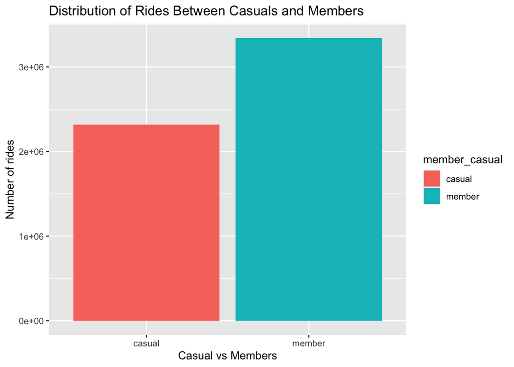

```r
ggplot(all_rides_v1, aes(x = member_casual, fill = member_casual)) +
  geom_bar() +
  labs(x = "Casual vs Members", y = "Number of rides", title = "Distribution of Rides Between Casuals and Members")
```

Based on the analysis, we’ve determined that `Casual` riders make up approximately 40.9% of the total rides, while `Members` contribute to roughly 59.1% of the rides within the dataset. This finding offers valuable insights into the distribution of rides between these two user categories.

**Analysis of Ride Length Statistics for Casual and Member Riders (Mean, Median, Minimum, Maximum)**

```r
all_rides_v1 %>%
  group_by(member_casual) %>%
  summarise(avg_ride_length = mean(ride_length), median_ride_length = median(ride_length),
            max_ride_length = max(ride_length), min_ride_length = min(ride_length))
```

```
## # A tibble: 2 × 5
##   member_casual avg_ride_length median_ride_length max_ride_length
##   <fct>                   <dbl>              <dbl>           <dbl>
## 1 casual                  1319.                778         2061244
## 2 member                   745.                530           89996
## # ℹ 1 more variable: min_ride_length <dbl>
```

- while casual riders tend to have longer average and maximum ride lengths, member riders exhibit shorter median ride lengths. The presence of extremely long rides among casual riders and consistent short rides for both groups suggests diverse riding behaviors within the dataset. Further analysis may help uncover the factors contributing to these variations.

**Examine the total number of rides and the average ride duration for both members and casual riders on a daily basis**

```r
# Prepare and Analyze Rides by Day of the Week

# In this code, we're first reordering the 'day_of_week' column to ensure it follows a logical order.
# We then group the data by 'member_casual' and 'day_of_week' to examine the number of rides and the
# average ride length for each day of the week, separately for members and casual riders.

# The results are summarized and arranged for better readability.

all_rides_v1$day_of_week <- ordered(all_rides_v1$day_of_week,
                            levels = c("Sunday", "Monday", "Tuesday", "Wednesday",
                                       "Thursday", "Friday", "Saturday"))

all_rides_v1 %>%
  group_by(member_casual, day_of_week) %>% # Group by member type and day of the week
  summarise(
    number_of_rides = n(),                # Count the number of rides
    average_ride_length = mean(ride_length), # Calculate the average ride length
    .groups = "drop"                      # Drop grouping for better presentation
  ) %>%
  arrange(member_casual, day_of_week)      # Arrange the results by member type and day of the week
```

```
## # A tibble: 14 × 4
##    member_casual day_of_week number_of_rides average_ride_length
##    <fct>         <ord>                 <int>               <dbl>
##  1 casual        Sunday               387981               1506.
##  2 casual        Monday               277032               1358.
##  3 casual        Tuesday              263162               1178.
##  4 casual        Wednesday            273808               1140.
##  5 casual        Thursday             308683               1181.
##  6 casual        Friday               333907               1232.
##  7 casual        Saturday             472027               1479.
##  8 member        Sunday               387089                822.
##  9 member        Monday               473219                720.
## 10 member        Tuesday              518473                709.
## 11 member        Wednesday            523739                710.
## 12 member        Thursday             532114                721.
## 13 member        Friday               466953                734.
## 14 member        Saturday             443141                828.
```

**Visualize total and average rides by type and day of week**

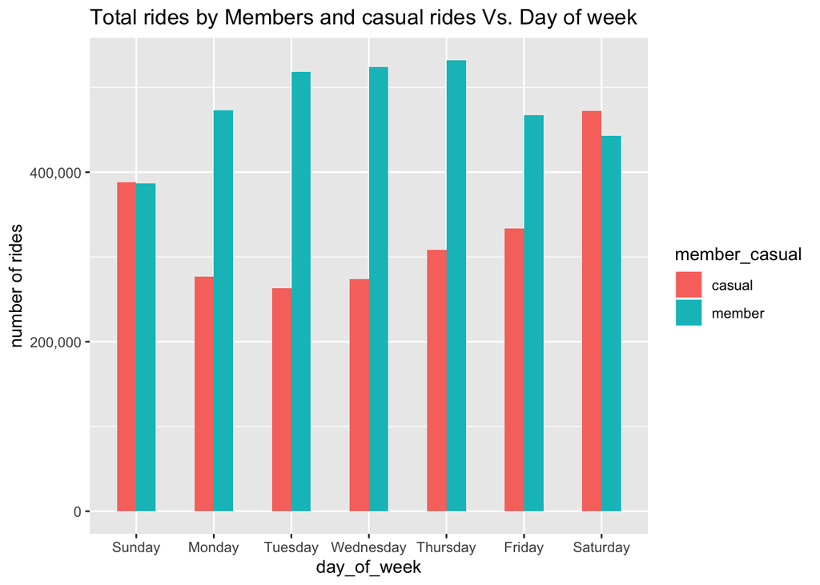

```r
all_rides_v1 %>%
  group_by(member_casual, day_of_week) %>%
  summarise(number_of_rides = n(), .groups = "drop") %>%
  arrange(member_casual, day_of_week) %>%
  ggplot(aes(x = day_of_week, y = number_of_rides, fill = member_casual)) +
  geom_col(width = 0.5, position = position_dodge(width = 0.5)) +
  labs(
    title = "Total rides by Members and casual rides Vs. Day of week",
    y = "number of rides"
    )+
  scale_y_continuous(labels = scales:: comma)
```

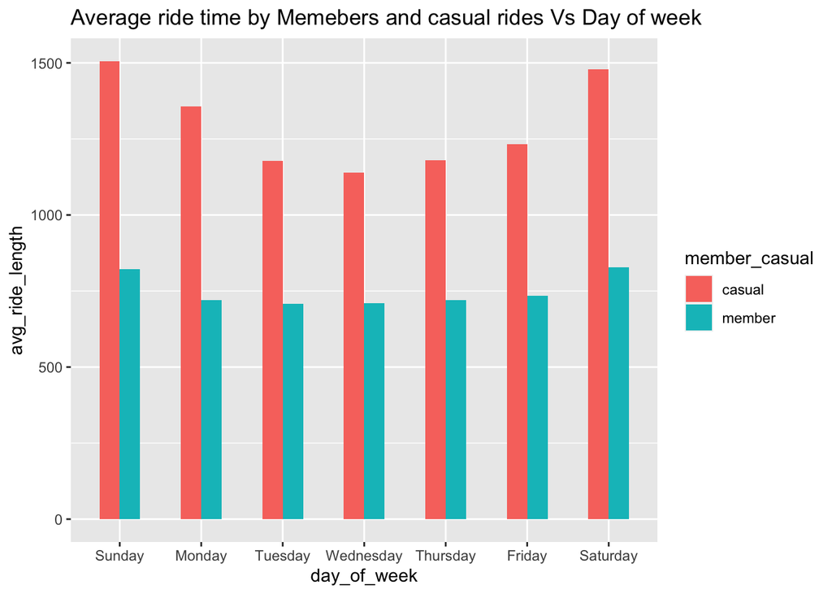

```r
all_rides_v1 %>%
  group_by(member_casual, day_of_week) %>%
  summarise(avg_ride_length = mean(ride_length), .groups = "drop") %>%
  ggplot(aes(x = day_of_week, y = avg_ride_length, fill = member_casual))+
  geom_col(width = 0.5, position = position_dodge(width = 0.5))+
  labs(title = "Average ride time by Memebers and casual rides Vs Day of week")
```

**Examine the total number of rides and the average ride duration for both members and casual riders on a monthly basis.**

```r
# we first reorder the 'month' column to ensure a logical order.
# Then, we group the data by 'member_casual' and 'month' to calculate the total number of rides
# and the average ride length for each month, separately for members and casual riders.

# The results are summarized and arranged for better visualization.

all_rides_v1$month <- ordered(all_rides_v1$month,
                              levels = c("January", "February", "March", "April",
                                         "May", "June", "July", "August", "September",
                                         "October", "November", "December"))

ride_length_month <- all_rides_v1 %>%
  group_by(member_casual, month) %>%
  summarise(
    number_of_rides = n(),        # Count the number of rides
    avg_ride_length = mean(ride_length),  # Calculate the average ride length
    .groups = "drop"              # Drop grouping for better presentation
  ) %>%
  arrange(member_casual, month)    # Arrange the results by member type and month

view(ride_length_month)  # Display the resulting data frame
```

**Vizualise total and average rides by type and monnth**

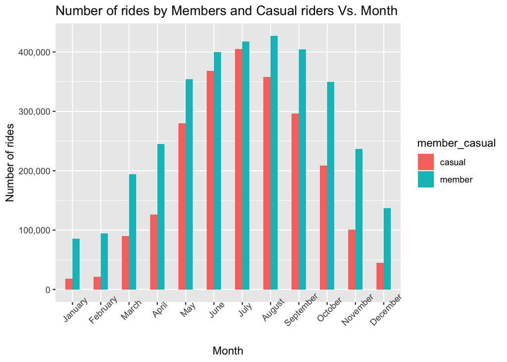

```r
all_rides_v1 %>%
  group_by(member_casual, month) %>%
  summarise(number_of_rides = n(), .groups = "drop") %>%
  arrange(member_casual, month) %>%
  ggplot(aes(x = month, y = number_of_rides, fill = member_casual))+
  labs(title = "Number of rides by Members and Casual riders Vs. Month", x = "Month", y= "Number of rides")+
  theme(axis.text.x = element_text(angle = 45))+
  geom_col(width = 0.5, position = position_dodge(width = 0.5))+
  scale_y_continuous(labels = scales :: comma)
```

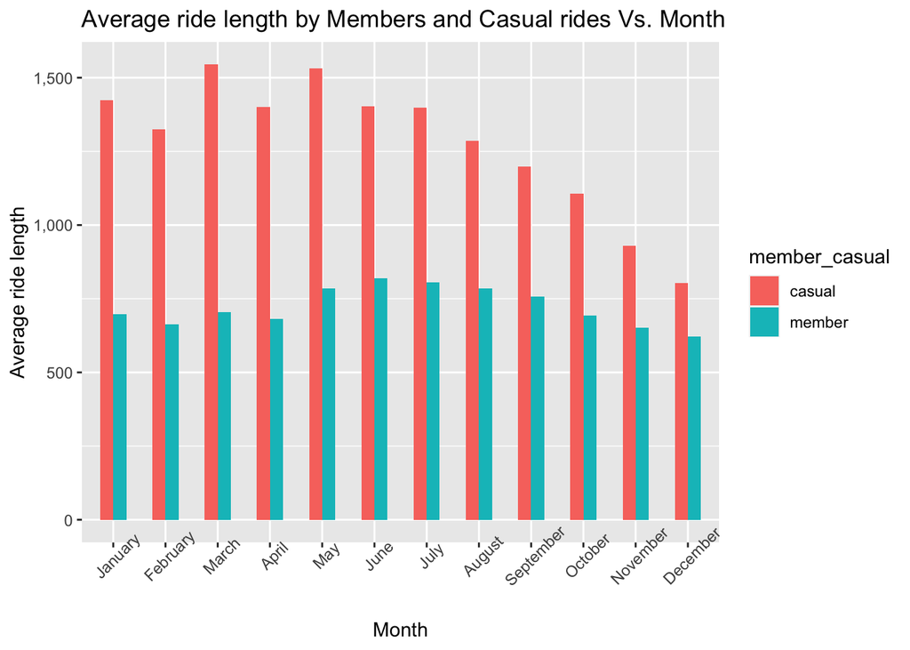

```r
all_rides_v1 %>%
  group_by(member_casual, month) %>%
  summarise(number_of_rides = n(), avg_ride_length = mean(ride_length), .groups = "drop") %>%
  arrange(member_casual, month) %>%
  ggplot(aes(x = month, y = avg_ride_length, fill = member_casual))+
  labs(title = "Average ride length by Members and Casual rides Vs. Month", x = "Month", y = "Average ride length")+
  theme(axis.text.x = element_text(angle = 45))+
  geom_col(width = 0.5, position = position_dodge(width = 0.5))+
  scale_y_continuous(labels = scales :: comma)
```

**Comparison between Members and Casual riders depending on ride distance**

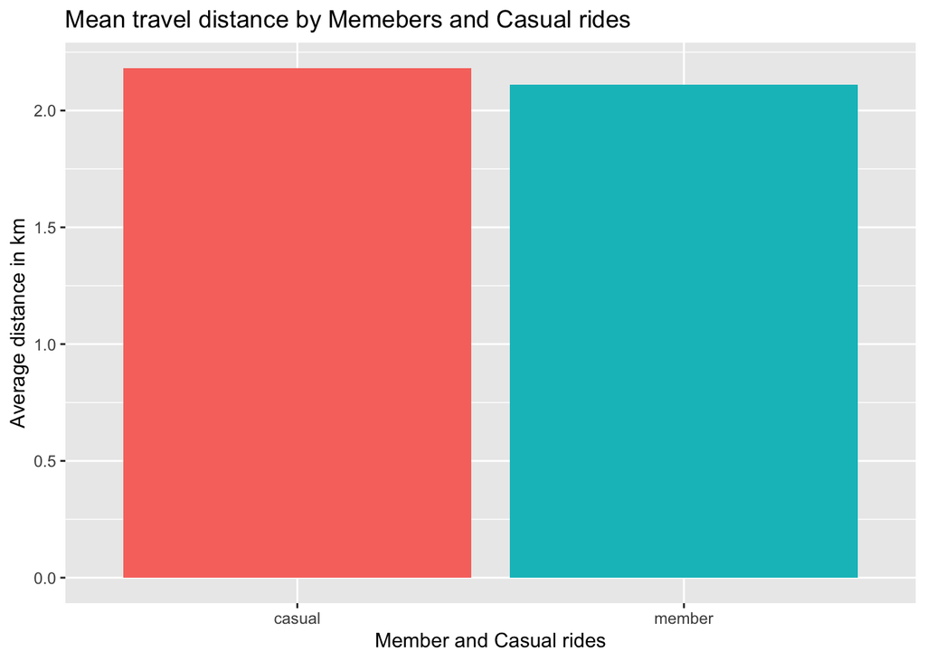

```r
all_rides_v1 %>%
  group_by(member_casual) %>%
  summarise(avg_ride_dist = mean(ride_distance)) %>%
  ggplot()+
  geom_col(mapping = aes(x = member_casual, y = avg_ride_dist, fill = member_casual),
           show.legend = FALSE)+
  labs(title = "Mean travel distance by Memebers and Casual rides", x = "Member and Casual rides", y = "Average distance in km")
```

- The chart indicates that both member and casual riders cover a similar average distance. This similarity might be because members take rides consistently throughout the week, while casual riders tend to ride mostly on weekends, often resulting in longer ride times.

**Vizualization of bike demand by hour in a day**

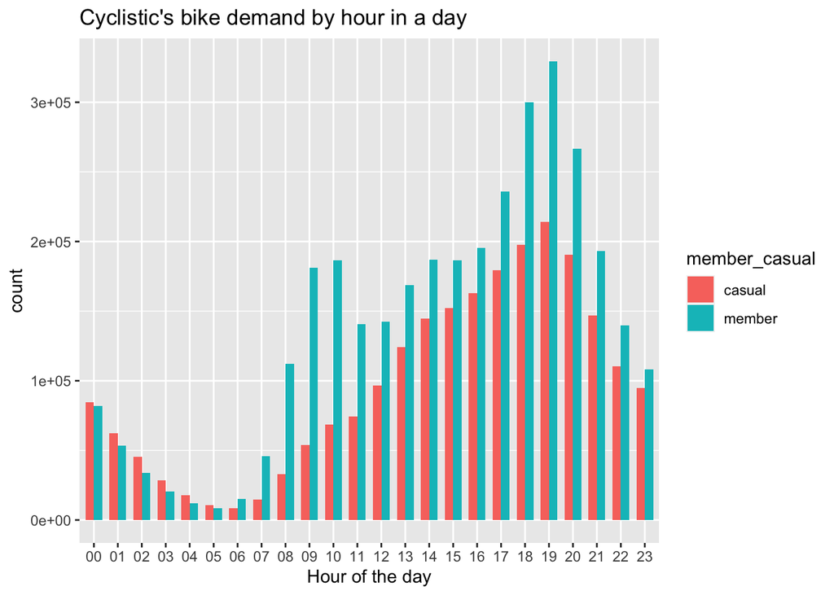

```r
all_rides_v1 %>%
  ggplot(aes(start_time, fill = member_casual))+
  labs(x= "Hour of the day", title = "Cyclistic's bike demand by hour in a day")+
  geom_bar(width = 0.7, position = position_dodge(width = 0.7))
```

- From the above chart we can see more members tend to take a ride between 8am and 10am in the morning and 5pm and 8pm in the afternoon, however, Casuals between 5pm and 8pm. Also there is bigger volume rise in the afternoon for both type of riders. This information needs to be checked on day basis.

**Taking a closer look and creating visuals for how Cyclistic’s bikes are used at different hours on each day of the week**

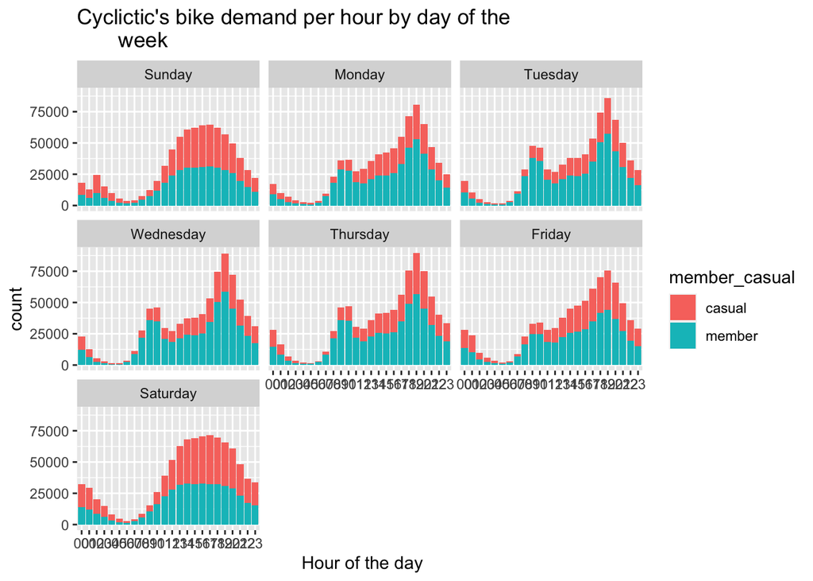

```r
all_rides_v1 %>%
  ggplot(aes(start_time, fill= member_casual))+
  geom_bar()+
  labs(x = " Hour of the day", title = "Cyclictic's bike demand per hour by day of the
       week")+
  facet_wrap(~day_of_week)
```

**Rideable type Vs. total rides by members and casuals**

```r
all_rides_v1 %>%
  group_by(member_casual, rideable_type) %>%
  summarise(count = length(ride_id))
```

```
## # A tibble: 5 × 3
## # Groups:   member_casual [2]
##   member_casual rideable_type   count
##   <fct>         <chr>           <int>
## 1 casual        classic_bike   888853
## 2 casual        docked_bike    174852
## 3 casual        electric_bike 1252895
## 4 member        classic_bike  1708993
## 5 member        electric_bike 1635735
```

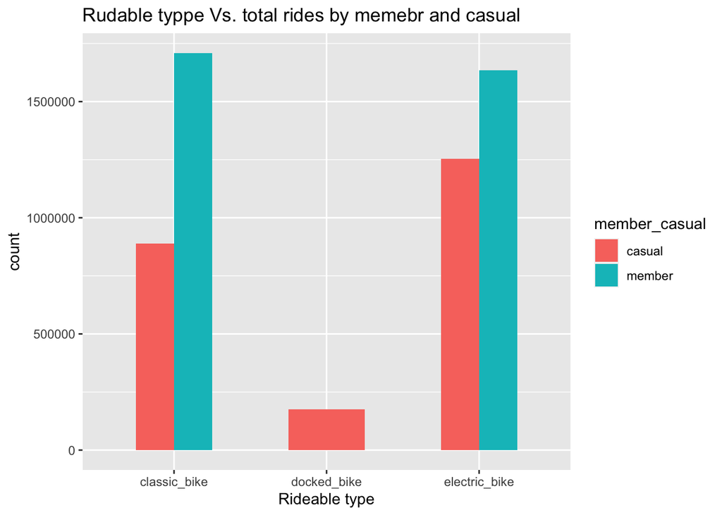

```r
ggplot(all_rides_v1, aes(x = rideable_type, fill = member_casual))+
  labs(x = "Rideable type", title = "Rudable typpe Vs. total rides by memebr and casual")+
  geom_bar(width = 0.5, position = position_dodge(width = 0.5))
```

- From the above chart we can see members mostly use classic bikes followed by electric bikes.Docked bikes used only by casual riders. Electric and classic bikes are more favored by members

**Creating Filtered Dataframes Based on Rider Type**

- Here, we are creating two separate dataframes, one for casual riders and another for member riders, based on their rider type. This allows us to analyze and compare location coordinates for rides where there have been more than 200 rides.

```r
# Filtering Coordinates Dataframe
coordinates_df <- all_rides_v1 %>%
  filter(start_lng != end_lng & start_lat != end_lat) %>%
  group_by(start_lng, start_lat, end_lng, end_lat, member_casual, rideable_type) %>%
  summarise(total_rides = n(), .groups = "drop") %>%
  filter(total_rides > 200)

# Creating Dataframes for Casual and Member Riders
casual_riders <- coordinates_df %>% filter(member_casual == "casual")
member_riders <- coordinates_df %>% filter(member_casual == "member")
```

**Generating Chicago Map**

- Here, we are generating a map of Chicago using the get_stamenmap function. We define the map’s bounding box with specific coordinates and zoom level, and we specify the map type as “terrain.”

```r
chicago_map <- get_stamenmap(
  bbox = c(
    left = -87.700424,
    bottom = 41.790769,
    right = -87.554855,
    top = 41.990119
  ),
  zoom = 12,
  maptype = "terrain"
)
```

**Creating Point Maps for Casual and Member Riders**

- In this code, we are creating point maps to visualize the most used routes by casual and member riders on the Chicago map

[output not shown]

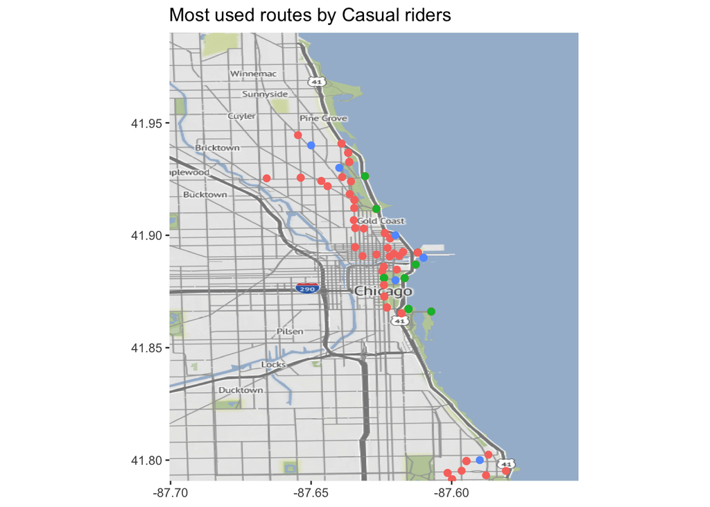

```r
# Create a point map for Casual Riders
ggmap(chicago_map, darken = c(0.1, "white")) +
  geom_point(data = casual_riders, aes(x = start_lng, y = start_lat, color =
  rideable_type), size = 2) +
coord_fixed(0.8) +  # Fix the aspect ratio
labs(title = "Most used routes by Casual riders", x = NULL, y = NULL) +
theme(legend.position = "none")
```

[output not shown]

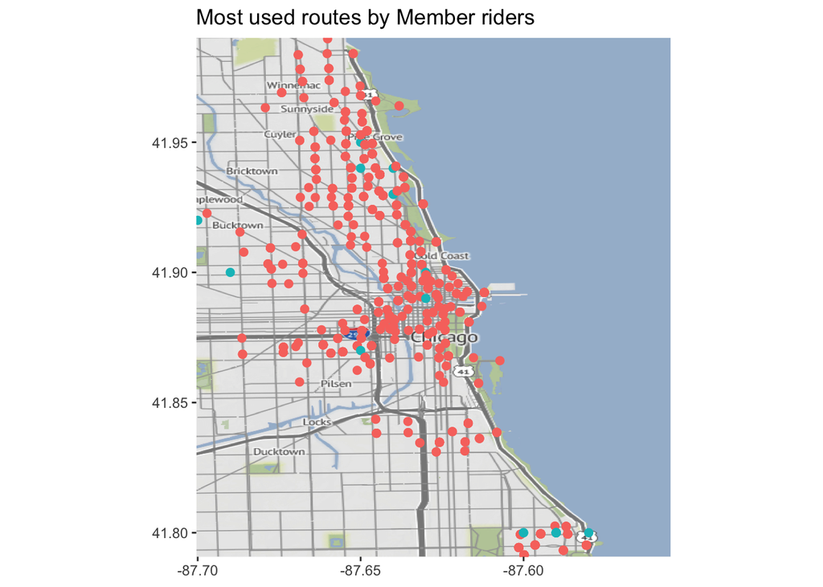

```r
# Overlay the Chicago map with the Casual Rider points
ggmap(chicago_map, darken = c(0.1, "white")) +
  geom_point(data = member_riders, aes(x = start_lng, y = start_lat, color=
  rideable_type), size = 2) +
coord_fixed(0.8) +  # Fix the aspect ratio
labs(title = "Most used routes by Member riders", x = NULL, y = NULL) +
theme(legend.position = "none")
```

- The visuals clearly show that casual riders tend to stick around the city center or bay area, suggesting they use bikes mainly for leisure, possibly tourist activities or sightseeing.
- In contrast, members use bikes throughout the city, including the main city area and its surroundings. This hints that members may be using bikes for work-related purposes, indicating a wider range of daily commuting and travel needs.

##Share

This phase can be done throgh presentation, however, we can use notebook to share our findings.

**key tasks**

- determine the best way to share your findings
- create effective data vizualization
- present your findings
- ensure your work is accessible

**Deliverable**

- supporting vizualizaton and findings

**Main insights and findings**

*1. Rider Type Behavior:*

- Casual riders tend to use bike-sharing services for leisure activities, with a significant increase in rides during weekends and longer average ride lengths. Members, on the other hand, maintain consistent usage throughout the week, likely for daily commuting and work-related travel. Members account for approximately 59.1% of total rides, while casual riders make up about 40.9% of rides.

*2. Seasonal Patterns:*

- Busiest months for both rider types are June, July, August, and September, indicating a peak in bike usage during the summer months. Winter months, such as November, December, January, and February, see a drop in total rides, especially among casual riders.

*4. Geographic Patterns:*

- Casual riders tend to concentrate their rides around the city center or bay area, suggesting leisure or tourist-related rides. Member riders have a broader distribution of rides, covering the main city area and its surroundings, indicating a likely focus on work-related and daily commuting purposes.

**Members vs. Casuals: Key Differences**

## Act

Act phase will be done by the Cyclistic’s executive team, Director of Marketing (Lily Moreno), Marketing Analytics team on the basis of my analysis. (Data-driven decision making)